# Zadanie 6

### Katastrofa promu Challenger

28 stycznia 1986 roku, prom kosmiczny Challenger eksplodował 73 sekundy po starcie. Wszyscy członkowie załogi zmarli. Śledztwo wykazało, że przyczyną katastofy była awaria o-ringu na prawej rakiecie wspomagającej na paliwo stałe (*Space Shuttle Solid Rocket Booster*). O-ringi służyły do wzmocnienia łączenia poszczególnych segmentów rakiety. Stwierdzono, że głównym powodem awarii o-ringa była wyjątkowo niska temperatura powietrza w chwili startu, wynosząca ok. 31 F (-0.6 C). Celem zadania jest oszacowanie prawdopodobieństwa awarii o-ringu w funkcji temperatury.

**1. (1 pkt)** Wczytaj dane z pliku `orings.txt`. Kolumna `temp` zawiera temperaturę w stopniach Fahrenheita, natomiast binarna zmienna `fail` informuje o tym czy nastąpiła awaria o-ringu. Przelicz temperaturę na stopnie Celcjusza i wykonaj wykres punktowy ilustrujący dane.

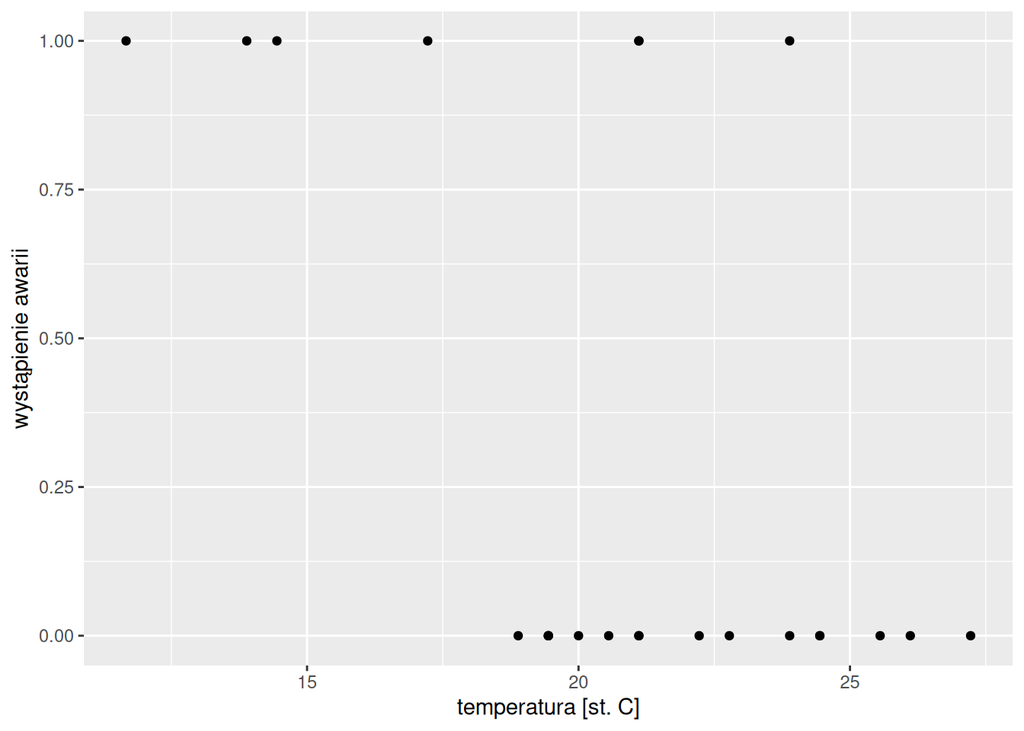

**2. (1 pkt)** Wykonaj regresję logistyczną dla zmiennej wynikowej `fail` w funkcji zmiennej objaśniającej `tempC`. Odpowiedz na pytanie czy otrzymany model jest statystycznie uzasadniony na poziomie ufności $\alpha = 0.05$?

```
##
## Call:
## glm(formula = fail ~ tempC, family = binomial, data = orings)
##
## Deviance Residuals:
##     Min       1Q   Median       3Q      Max
## -1.0611  -0.7613  -0.3783   0.4524   2.2175
##
## Coefficients:
##             Estimate Std. Error z value Pr(>|z|)
## (Intercept)   7.6137     3.9334   1.936   0.0529 .
## tempC        -0.4179     0.1948  -2.145   0.0320 *
## ---
## Signif. codes:  0 '***' 0.001 '**' 0.01 '*' 0.05 '.' 0.1 ' ' 1
##
## (Dispersion parameter for binomial family taken to be 1)
##
##     Null deviance: 28.267  on 22  degrees of freedom
## Residual deviance: 20.315  on 21  degrees of freedom
## AIC: 24.315
##
## Number of Fisher Scoring iterations: 5
```

**3. (1 pkt)** Ilukrotnie zmieni się szansa awarii jeśli temperatura powietrza spadnie z 15 na 10 stopni Celcjusza?

```
##    tempC
## 8.080588
```

**4. (1 pkt)** Przy pomocy funkcji `predict()` wyznacz prawdopobieństwa awarii w funkcji temperatury dla przedziału od 1 do 30 stopni Celcjusza z różnicą 1 stopnia. O ile zmieni się prawdopodobieństwo awarii jeśli temperatura powietrza spadnie z 15 na 10 stopni Celcjusza?

```
## [1] 0.1754134
```

**5. (1 pkt)** Zobrazuj dane z pkt. 4 w formie czerwonej linii dodanej do rysunku z pkt. 1.

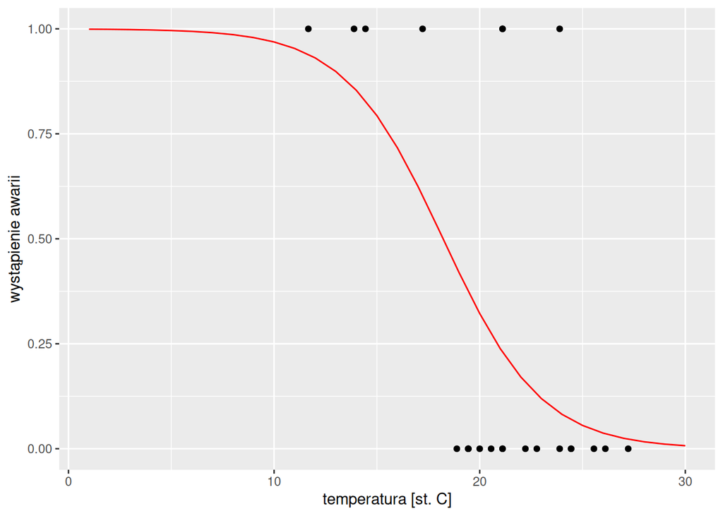